# 삼국지

삼국지 스탯(stat)

xwMOOC

2018-01-21

## 1. 코에이 삼국지 [^1] [^2]

일본의 코에이 테크모에서 개발/발매하는 PC용 삼국지 기반 역사 시뮬레이션 게임으로 2세기 말 ~ 3세기 중반 중국의 후한 말기 및 삼국시대를 역사적 배경으로 한다.

코에이 삼국지의 역사적인 배경은 다음과 같다.

- 184년 황건의 난: 하진, 장각, 손견, 동탁, 마등, 공손찬, 유언, 정원 등
- 190년 반동탁연합: 조조, 유비, 손견, 동탁, 원소, 유표, 원술, 유언, 마등, 공손찬, 도겸 등
- 195년 군웅할거 : 조조, 유비, 손책, 여포, 원소, 유표, 원술, 유장, 마등, 공손찬 등
- 198년 여포토벌전: 조조, 유비, 손책, 여포, 원소, 유표, 원술, 유장, 마등, 공손찬 등
- 200년 관도전투: 조조, 유비, 손권(손책), 원소, 유표, 유장, 마등, 장로 등
- 207년 삼고초려: 조조, 유비, 손권, 유표, 유장, 마등, 장로 등
- 208년 적벽대전: 조조, 유비, 손권, 유표, 유장, 마등, 장로 등
- 215년 ~ 223년 삼국정립 ~ 이릉대전/오로침공전: 조조(조비), 유비(유선), 손권, 공손공, 맹획 등

### 1.1. 코에이 삼국지 발매년도 [^3]

코에이 삼국지 발매년도는 다음과 같다.

- 삼국지 1 (1985년) (PC, FC, SFC, SS, PS1)
- 삼국지 2 (1989년) (PC, FC, SFC, MD, PS1, GBC, WS, iOS, Android)
- 삼국지 3 (1992년) (PC, SFC, MD, MCD, PCE, PS1, DS, 3DS)
- 삼국지 4 (1994년) (PC, SFC, 3DO, SS, 32X, PS1, GBA, DS)
- 삼국지 5 (1996년) (PC, SS, PS1, PSP, DS, 3DS)
- 삼국지 6 (1998년) (PC, PS1, DC, PSP)
- 삼국지 7 (2000년) (PC, PS1, PS2, PSP)
- 삼국지 8 (2001년) (PC, PS2, PSP)
- 삼국지 9 (2003년) (PC, PS2, PSP)
- 삼국지 10 (2004년) (PC, PS2)
- 삼국지 11 (2006년) (PC, PS2, Wii)
- 삼국지 12 (2012년) (PC, PS3, Wii U, PS Vita)
- 삼국지 13 (2016년) (PC, PS3, PS4, XBO, PS Vita, SW)

## 2. 삼국지 스탯(stat)

### 2.1. 삼국지 10 스탯

```r
library(rvest)
library(tidyverse)
library(lubridate)
library(extrafont)
loadfonts()

# 1. 데이터 가져오기 -----
Sys.setlocale("LC_ALL", "C")
```

```
[1] "C"
```

```r
## 1.1. 삼국지 10 능력치
tk_10_url <- "https://zetawiki.com/wiki/%EC%82%BC%EA%B5%AD%EC%A7%80_10_%EB%8A%A5%EB%A0%A5%EC%B9%98_%EB%AA%A9%EB%A1%9D"

## 인코딩 확인
tk_10_url_encoding <- httr::content(httr::GET(tk_10_url), "raw")
# guess_encoding(tk_10_url_encoding)

tk_10_dat <- tk_10_url %>%
  read_html(tk_10_url) %>%
  html_nodes(xpath='//*[@id="mw-content-text"]/table') %>%
  html_table(fill = TRUE) %>%
  .[[1]]

Sys.setlocale("LC_ALL", "Korean")
```

```
[1] "LC_COLLATE=Korean_Korea.949;LC_CTYPE=Korean_Korea.949;LC_MONETARY=Korean_Korea.949;LC_NUMERIC=C;LC_TIME=Korean_Korea.949"
```

```r
DT::datatable(tk_10_dat)
```

|  | 이름(한글) | 이름(한자) | 등장연도 | 탄생연도 | 통솔 | 무력 | 지력 | 정치 | 매력 | 능력종합 | 세력상성 | 개인상성 |
| --- | --- | --- | --- | --- | --- | --- | --- | --- | --- | --- | --- | --- |
| 1 | 가규 | 賈逵 | 199 | 177 | 75 | 62 | 80 | 86 | 78 | 381 | 29 | 134 |
| 2 | 가범 | 賈範 | 221 | 202 | 59 | 60 | 73 | 64 | 61 | 317 | 136 | 144 |
| 3 | 가비능 | 軻比能 | 191 | 172 | 77 | 69 | 52 | 59 | 68 | 325 | 49 | 84 |
| 4 | 가충 | 賈充 | 231 | 217 | 33 | 32 | 88 | 88 | 8 | 249 | 31 | 121 |
| 5 | 가화 | 賈華 | 195 | 176 | 50 | 66 | 40 | 29 | 53 | 238 | 123 | 15 |
| 6 | 가후 | 賈詡 | 184 | 147 | 81 | 45 | 98 | 84 | 56 | 364 | 20 | 84 |
| 7 | 간옹 | 簡雍 | 184 | 164 | 22 | 33 | 66 | 71 | 74 | 266 | 75 | 69 |
| 8 | 감녕 | 甘寧 | 193 | 174 | 88 | 93 | 75 | 20 | 55 | 331 | 129 | 71 |
| 9 | 강단 | 強端 | 189 | 168 | 58 | 83 | 9 | 11 | 29 | 190 | 60 | 94 |
| 10 | 강유 | 姜維 | 225 | 202 | 91 | 89 | 90 | 68 | 77 | 415 | 73 | 17 |

[output cut: 640 more lines]

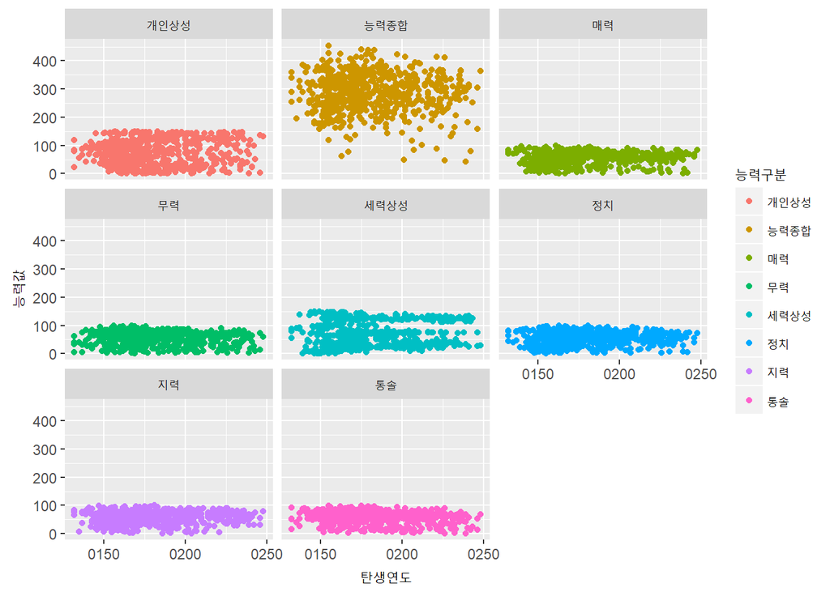

```r
# 2. 데이터 정제 -----

tk_10_df <- tk_10_dat %>%
  select(이름 = `이름(한글)`, 한문명=`이름(한자)`, everything()) %>%
  mutate(등장연도 = make_date(year=등장연도)) %>%
  mutate(탄생연도 = make_date(year=탄생연도)) %>%
  tbl_df() %>%
  filter(이름 != "양서") # 세력상성 782 오류

# 3. 시각화 -----
## 3.0. 시각화 데이터 -----
tk_10_viz_df <- tk_10_df %>%
  gather(능력구분, 능력값, 통솔:개인상성)

## 3.1. 시각화 데이터 -----
ggplot(tk_10_viz_df, aes(x=탄생연도, y=능력값, group=능력구분, color=능력구분)) +
    geom_point() +
    facet_wrap(~능력구분)
```

### 2.2. 삼국지 11 스탯

```r
# 1. 데이터 가져오기 -----

Sys.setlocale("LC_ALL", "C")
```

```
[1] "C"
```

```r
## 1.1. 삼국지 10 능력치
tk_11_url <- "https://zetawiki.com/wiki/%EC%82%BC%EA%B5%AD%EC%A7%80_11_%EB%8A%A5%EB%A0%A5%EC%B9%98_%EB%AA%A9%EB%A1%9D"

## 인코딩 확인
tk_11_url_encoding <- httr::content(httr::GET(tk_11_url), "raw")
# guess_encoding(tk_11_url_encoding)

tk_11_dat <- tk_11_url %>%
  read_html(tk_11_url) %>%
  html_nodes(xpath='//*[@id="mw-content-text"]/table') %>%
  html_table(fill = TRUE) %>%
  .[[1]]

Sys.setlocale("LC_ALL", "Korean")
```

```
[1] "LC_COLLATE=Korean_Korea.949;LC_CTYPE=Korean_Korea.949;LC_MONETARY=Korean_Korea.949;LC_NUMERIC=C;LC_TIME=Korean_Korea.949"
```

```r
DT::datatable(tk_11_dat)
```

|  | 이름 | 통솔 | 무력 | 지력 | 정치 | 매력 | 능력종합 | 출생년도 | 사망년도 | 등장년도 | 출신지 | 소재지 |
| --- | --- | --- | --- | --- | --- | --- | --- | --- | --- | --- | --- | --- |
| 1 | 가규 | 78 | 61 | 84 | 85 | 75 | 383 | 177 | 231 | 199 | 사례 | 낙양 |
| 2 | 가범 | 60 | 62 | 73 | 62 | 62 | 319 | 202 | 237 | 221 | 유주 | 양평 |
| 3 | 가충 | 54 | 31 | 89 | 85 | 10 | 269 | 217 | 282 | 231 | 사례 | 낙양 |
| 4 | 가화 | 49 | 65 | 41 | 29 | 52 | 236 | 176 | 224 | 195 | 양주 | 여강 |
| 5 | 가후 | 86 | 48 | 97 | 85 | 57 | 373 | 147 | 223 | 184 | 양주 | 무위 |
| 6 | 간옹 | 20 | 32 | 74 | 71 | 74 | 271 | 164 | 225 | 184 | 유주 | 계 |
| 7 | 감녕 | 86 | 94 | 76 | 18 | 58 | 332 | 174 | 222 | 193 | 익주 | 강주 |
| 8 | 감택 | 43 | 49 | 83 | 86 | 73 | 334 | 182 | 243 | 201 | 양주 | 회계 |
| 9 | 강유 | 90 | 89 | 90 | 67 | 80 | 416 | 202 | 264 | 225 | 양주 | 천수 |
| 10 | 건석 | 16 | 7 | 78 | 62 | 18 | 181 | 155 | 189 | 184 | 유주 | 낙양 |

[output cut: 666 more lines]

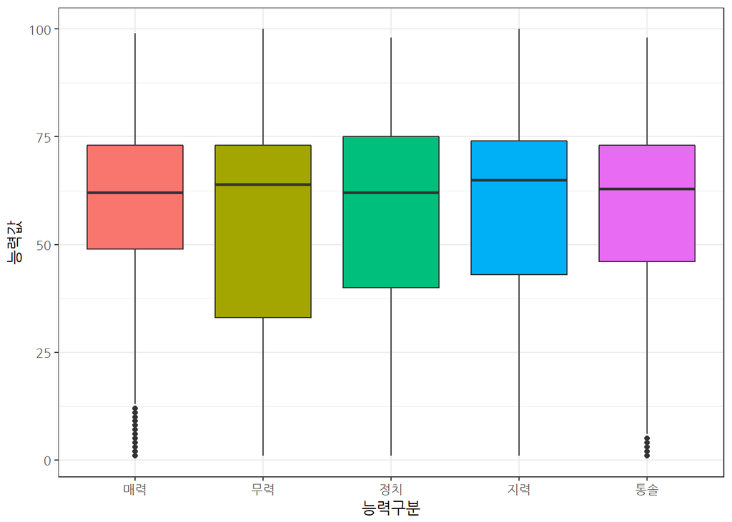

```r
# 2. 데이터 정제 -----

tk_11_df <- tk_11_dat %>%
  mutate(등장년도 = make_date(year=등장년도)) %>%
  mutate(출생년도 = make_date(year=출생년도)) %>%
  mutate(사망년도 = make_date(year=사망년도)) %>%
  tbl_df()

# 3. 시각화 -----
## 3.0. 시각화 데이터 -----
tk_11_viz_df <- tk_11_df %>%
  gather(능력구분, 능력값, 통솔:능력종합)

tk_11_viz_df %>%
  filter(능력구분 != "능력종합") %>%
  ggplot(aes(x=능력구분, y=능력값, fill=능력구분)) +
  geom_boxplot() +
  theme_bw(base_family = "NanumGothic") +
  theme(legend.position = "none")
```

### 2.3. 삼국지 12 스탯

```r
# 1. 데이터 가져오기 -----
Sys.setlocale("LC_ALL", "C")
```

```
[1] "C"
```

```r
## 1.1. 삼국지 12 능력치
tk_12_url <- "https://zetawiki.com/wiki/%EC%82%BC%EA%B5%AD%EC%A7%80_12_%EB%8A%A5%EB%A0%A5%EC%B9%98_%EB%AA%A9%EB%A1%9D"

## 인코딩 확인
tk_12_url_encoding <- httr::content(httr::GET(tk_12_url), "raw")
# guess_encoding(tk_12_url_encoding)

tk_12_dat <- tk_12_url %>%
  read_html(tk_11_url) %>%
  html_nodes(xpath='//*[@id="mw-content-text"]/table') %>%
  html_table(fill = TRUE) %>%
  .[[1]]

Sys.setlocale("LC_ALL", "Korean")
```

```
[1] "LC_COLLATE=Korean_Korea.949;LC_CTYPE=Korean_Korea.949;LC_MONETARY=Korean_Korea.949;LC_NUMERIC=C;LC_TIME=Korean_Korea.949"
```

```r
DT::datatable(tk_12_dat)
```

|  | 이름 | 통솔 | 무력 | 지력 | 정치 | 능력종합 | 병과 | 전법 |
| --- | --- | --- | --- | --- | --- | --- | --- | --- |
| 1 | 가규 | 78 | 61 | 84 | 85 | 308 | 창병 | 맹사봉인 |
| 2 | 가충 | 54 | 31 | 89 | 85 | 259 | 궁병 | 지력저하 |
| 3 | 가화 | 49 | 65 | 41 | 29 | 184 | 창병 | 기동력약화 |
| 4 | 가후 | 88 | 48 | 97 | 85 | 318 | 기병 | 허유엄살 |
| 5 | 간옹 | 20 | 32 | 75 | 71 | 198 | 창병 | 파괴력약화 |
| 6 | 감녕 | 93 | 94 | 76 | 18 | 281 | 창병 | 맹공 |
| 7 | 감씨 | 47 | 3 | 48 | 60 | 158 | 궁병 | 문무저하 |
| 8 | 감택 | 43 | 49 | 83 | 86 | 261 | 창병 | 지력상승 |
| 9 | 강유 | 92 | 89 | 90 | 67 | 338 | 창병 | 공방일체 |
| 10 | 견씨 | 35 | 4 | 72 | 66 | 177 | 기병 | 문무저하 |

[output cut: 463 more lines]

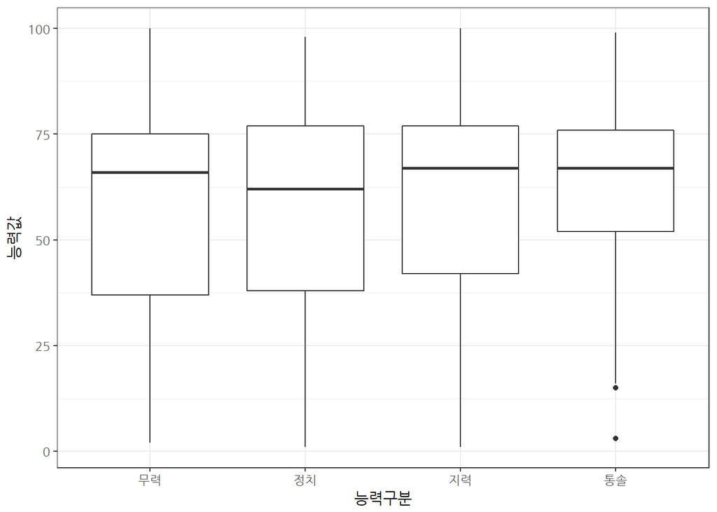

```r
# 2. 데이터 정제 -----

tk_12_df <- tk_12_dat %>%
  tbl_df()

# 3. 시각화 -----
## 3.0. 시각화 데이터 -----
tk_12_viz_df <- tk_12_df %>%
  gather(능력구분, 능력값, 통솔:능력종합)

## 3.1. 능력종합 vs 매력 -----
tk_12_viz_df %>%
  filter(능력구분 != "능력종합") %>%
  ggplot(aes(x=능력구분, y=능력값)) +
    geom_boxplot() +
    theme_bw(base_family = "NanumGothic") +
    theme(legend.position = "none")
```

[^1]: [나무 위키, 삼국지 시리즈](https://namu.wiki/w/%EC%82%BC%EA%B5%AD%EC%A7%80%20%EC%8B%9C%EB%A6%AC%EC%A6%88)
[^2]: [인스티즈, 역대 코에이 삼국지 시리즈 1부터 12까지 알아보자!!!](https://www.instiz.net/clip/704651)
[^3]: [나무위키, 삼국지 시리즈 (r741 판)](https://namu.wiki/w/%EC%82%BC%EA%B5%AD%EC%A7%80%20%EC%8B%9C%EB%A6%AC%EC%A6%88?rev=741?noredirect=1)